# INVESTIGATE A DATASET - TMDb movie data set

May 2 -2020

#### NIMMY GEORGE

Project 2

Udacity- Data Analyst Nanodegree

```
1.Introduction
2.Data Wrangling
3.Exploratory Data Analysis
4.Conclusions
```

#### INTRODUCTION

In this project, I have investigated the dataset on the TMDb movie dataset. I have been provided with various datasets in the Udacity portal from where I have to extract, manipulate and visualize the data and have to answer certain questions I have come up with and find felicitous answers utilizing by data analytic and data visualization skills.

#### Questions to answer (These are the certain question I have come up eith to analyse and investigate)

1.Which genres are hottest from year to year?

2.What sorts of properties are related to movies that have high revenues?

3.Did movies with higher vote count received a far better rating?

4.What were the foremost popular produced genres in 2000 compared to 2015?

5.How did the quantity of produced films changed over time?

```python
%pylab inline
import pandas
import seaborn
```

# DATA WRANGLING

## Load CSV File into Memory

```python
data = pandas.read_csv('Desktop/tmdb-movies.csv')
```

```python
data.head()
```

|  | id | imdb_id | popularity | budget | revenue | original_title | cast | homepage | director | tagline | ... | overview | runtime | genres | production_companies | release_date | vote_count | vote_average | release_year | budget_adj | revenue_adj |
| --- | --- | --- | --- | --- | --- | --- | --- | --- | --- | --- | --- | --- | --- | --- | --- | --- | --- | --- | --- | --- | --- |
| 0 | 135397 | tt0369610 | 32.985763 | 150000000 | 1513528810 | Jurassic World | Chris Pratt\|Bryce Dallas Howard\|Irrfan Khan\|Vi... | http://www.jurassicworld.com/ | Colin Trevorrow | The park is open. | ... | Twenty-two years after the events of Jurassic ... | 124 | Action\|Adventure\|Science Fiction\|Thriller | Universal Studios\|Amblin Entertainment\|Legenda... | 6/9/15 | 5562 | 6.5 | 2015 | 1.379999e+08 | 1.392446e+09 |
| 1 | 76341 | tt1392190 | 28.419936 | 150000000 | 378436354 | Mad Max: Fury Road | Tom Hardy\|Charlize Theron\|Hugh Keays-Byrne\|Nic... | http://www.madmaxmovie.com/ | George Miller | What a Lovely Day. | ... | An apocalyptic story set in the furthest reach... | 120 | Action\|Adventure\|Science Fiction\|Thriller | Village Roadshow Pictures\|Kennedy Miller Produ... | 5/13/15 | 6185 | 7.1 | 2015 | 1.379999e+08 | 3.481613e+08 |
| 2 | 262500 | tt2908446 | 13.112507 | 110000000 | 295238201 | Insurgent | Shailene Woodley\|Theo James\|Kate Winslet\|Ansel... | http://www.thedivergentseries.movie/#insurgent | Robert Schwentke | One Choice Can Destroy You | ... | Beatrice Prior must confront her inner demons ... | 119 | Adventure\|Science Fiction\|Thriller | Summit Entertainment\|Mandeville Films\|Red Wago... | 3/18/15 | 2480 | 6.3 | 2015 | 1.012000e+08 | 2.716190e+08 |
| 3 | 140607 | tt2488496 | 11.173104 | 200000000 | 2068178225 | Star Wars: The Force Awakens | Harrison Ford\|Mark Hamill\|Carrie Fisher\|Adam D... | http://www.starwars.com/films/star-wars-episod... | J.J. Abrams | Every generation has a story. | ... | Thirty years after defeating the Galactic Empi... | 136 | Action\|Adventure\|Science Fiction\|Fantasy | Lucasfilm\|Truenorth Productions\|Bad Robot | 12/15/15 | 5292 | 7.5 | 2015 | 1.839999e+08 | 1.902723e+09 |
| 4 | 168259 | tt2820852 | 9.335014 | 190000000 | 1506249360 | Furious 7 | Vin Diesel\|Paul Walker\|Jason Statham\|Michelle ... | http://www.furious7.com/ | James Wan | Vengeance Hits Home | ... | Deckard Shaw seeks revenge against Dominic Tor... | 137 | Action\|Crime\|Thriller | Universal Pictures\|Original Film\|Media Rights ... | 4/1/15 | 2947 | 7.3 | 2015 | 1.747999e+08 | 1.385749e+09 |

5 rows × 21 columns

```python
data.info(),
print('-------------')
print('Dataframe contains {} rows and {} columns'.format(data.shape[0],data.shape[1]))
```

```
<class 'pandas.core.frame.DataFrame'>
RangeIndex: 10866 entries, 0 to 10865
Data columns (total 21 columns):
id                      10866 non-null int64
imdb_id                 10856 non-null object
popularity              10866 non-null float64
budget                  10866 non-null int64
revenue                 10866 non-null int64
original_title          10866 non-null object
cast                    10790 non-null object
homepage                2936 non-null object
director                10822 non-null object
tagline                 8042 non-null object
keywords                9373 non-null object
overview                10862 non-null object
runtime                 10866 non-null int64
genres                  10843 non-null object
production_companies    9836 non-null object
release_date            10866 non-null object
vote_count              10866 non-null int64
vote_average            10866 non-null float64
release_year            10866 non-null int64
budget_adj              10866 non-null float64
revenue_adj             10866 non-null float64
dtypes: float64(4), int64(6), object(11)
memory usage: 1.7+ MB
-------------
Dataframe contains 10866 rows and 21 columns
```

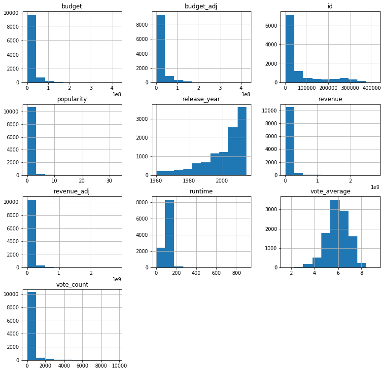

```python
data.hist(figsize=(13,13));
```

```python
data.describe()
```

|  | id | popularity | budget | revenue | runtime | vote_count | vote_average | release_year | budget_adj | revenue_adj |
| --- | --- | --- | --- | --- | --- | --- | --- | --- | --- | --- |
| count | 10866.000000 | 10866.000000 | 1.086600e+04 | 1.086600e+04 | 10866.000000 | 10866.000000 | 10866.000000 | 10866.000000 | 1.086600e+04 | 1.086600e+04 |
| mean | 66064.177434 | 0.646441 | 1.462570e+07 | 3.982332e+07 | 102.070863 | 217.389748 | 5.974922 | 2001.322658 | 1.755104e+07 | 5.136436e+07 |
| std | 92130.136561 | 1.000185 | 3.091321e+07 | 1.170035e+08 | 31.381405 | 575.619058 | 0.935142 | 12.812941 | 3.430616e+07 | 1.446325e+08 |
| min | 5.000000 | 0.000065 | 0.000000e+00 | 0.000000e+00 | 0.000000 | 10.000000 | 1.500000 | 1960.000000 | 0.000000e+00 | 0.000000e+00 |
| 25% | 10596.250000 | 0.207583 | 0.000000e+00 | 0.000000e+00 | 90.000000 | 17.000000 | 5.400000 | 1995.000000 | 0.000000e+00 | 0.000000e+00 |
| 50% | 20669.000000 | 0.383856 | 0.000000e+00 | 0.000000e+00 | 99.000000 | 38.000000 | 6.000000 | 2006.000000 | 0.000000e+00 | 0.000000e+00 |
| 75% | 75610.000000 | 0.713817 | 1.500000e+07 | 2.400000e+07 | 111.000000 | 145.750000 | 6.600000 | 2011.000000 | 2.085325e+07 | 3.369710e+07 |
| max | 417859.000000 | 32.985763 | 4.250000e+08 | 2.781506e+09 | 900.000000 | 9767.000000 | 9.200000 | 2015.000000 | 4.250000e+08 | 2.827124e+09 |

```python
data['revenue_adj'].replace(0, np.NAN, inplace=True)
data['revenue'].replace(0, np.NAN, inplace=True)
data['budget_adj'].replace(0, np.NAN, inplace=True)
data['budget'].replace(0, np.NAN, inplace=True)
data['runtime'].replace(0, np.NAN, inplace=True)

data.dropna(axis=0, inplace=True)
```

```python
data_c = (data['cast'].str.split('|', expand=True).rename(columns=lambda x: f"cast_{x+1}"))
data_d = (data['director'].str.split('|', expand=True).rename(columns=lambda x: f"director_{x+1}"))
data_k = (data['keywords'].str.split('|', expand=True).rename(columns=lambda x: f"keywords_{x+1}"))
data_g = (data['genres'].str.split('|', expand=True).rename(columns=lambda x: f"genres_{x+1}"))
data_p = (data['production_companies'].str.split('|', expand=True).rename(columns=lambda x: f"production_companies_{x+1}"))

#Checking df_c if split was conducted as intended
data_c.head()
```

|  | cast_1 | cast_2 | cast_3 | cast_4 | cast_5 |
| --- | --- | --- | --- | --- | --- |
| 0 | Chris Pratt | Bryce Dallas Howard | Irrfan Khan | Vincent D'Onofrio | Nick Robinson |
| 1 | Tom Hardy | Charlize Theron | Hugh Keays-Byrne | Nicholas Hoult | Josh Helman |
| 2 | Shailene Woodley | Theo James | Kate Winslet | Ansel Elgort | Miles Teller |
| 3 | Harrison Ford | Mark Hamill | Carrie Fisher | Adam Driver | Daisy Ridley |
| 4 | Vin Diesel | Paul Walker | Jason Statham | Michelle Rodriguez | Dwayne Johnson |

```python
data = data.join([data_c, data_d, data_k, data_g, data_p])
data = data.drop(['cast', 'keywords', 'director', 'genres', 'production_companies', 'imdb_id', 'homepage', 'overview', 'release_date', 'tagline'], axis=1)
```

```python
data.duplicated().sum()
```

```
0
```

```python
data.dtypes
```

```
id                          int64
popularity                float64
budget                    float64
revenue                   float64
original_title             object
runtime                   float64
vote_count                  int64
vote_average              float64
release_year                int64
budget_adj                float64
revenue_adj               float64
cast_1                     object
cast_2                     object
cast_3                     object
cast_4                     object
cast_5                     object
director_1                 object
director_2                 object
director_3                 object
director_4                 object
director_5                 object
director_6                 object
keywords_1                 object
keywords_2                 object
keywords_3                 object
keywords_4                 object
keywords_5                 object
genres_1                   object
genres_2                   object
genres_3                   object
genres_4                   object
genres_5                   object
production_companies_1     object
production_companies_2     object
production_companies_3     object
production_companies_4     object
production_companies_5     object
dtype: object
```

```python
data['original_title'].value_counts().head()
```

```
The Three Musketeers    2
The Fog                 2
The Thing               2
Halloween               2
Wanted                  2
Name: original_title, dtype: int64
```

```python
limit_4_title = data['original_title'].value_counts().index.tolist()
limit_4_title = limit_4_title[:4]
limit_4_title

limit_4_id = data['original_title'].value_counts().index.tolist()

def check_double_title(names):
    for limit in limit_4_title:
        data_title = data[data['original_title'] == limit]
        print(data_title.iloc[:,:5])
        print("---------------------------------------------------------------------")

check_double_title(limit_4_title)
```

```
          id  popularity      budget      revenue        original_title
3425   52451    1.407986  75000000.0  132274484.0  The Three Musketeers
10251  10057    0.794564  30000000.0   53898845.0  The Three Musketeers
---------------------------------------------------------------------
       id  popularity      budget     revenue original_title
6312  791    0.608364  18000000.0  46201432.0        The Fog
7324  790    0.659182   1000000.0  21378361.0        The Fog
---------------------------------------------------------------------
         id  popularity      budget     revenue original_title
3472  60935    1.013771  35000000.0  28128670.0      The Thing
8890   1091    2.355353  10000000.0  13782838.0      The Thing
---------------------------------------------------------------------
         id  popularity      budget     revenue original_title
7483   2082    0.809646  15000000.0  80253908.0      Halloween
10759   948    1.198849    300000.0  70000000.0      Halloween
---------------------------------------------------------------------
```

```python
print('Dataframe contains {} rows and {} columns'.format(data.shape[0],data.shape[1]))
```

```
Dataframe contains 1287 rows and 37 columns
```

# Research Question 1: Which genres are most popular from year to year?

```python
# Selecting genres columns for the analysis of the original data frame
data_genres = data.loc[:, 'genres_1': 'genres_5' ]
# Adding release year to data_genres
data_genres_dates = data_genres.join(data['release_year'])
```

```python
years = data_genres_dates['release_year'].unique() #creates an array of years mentioned in release year
most_common = [] #creates a list of tuples for most common genres in specific years

#for loop to create most_common list
for year in years:
    #creates data filtered by every year mentioned in years
    a = data_genres_dates[data_genres_dates['release_year'] == year]
    #drops columns "release_year to perferm stack value count in next line
    b = a.drop(['release_year'], axis = 1)
    #performs value count trough genres_1 - genres_5 and stores the index of maximum count
    c = b.stack().value_counts().idxmax()

    #creates a masked DataFrame for respective years
    x = data[data['release_year'] == year]
    #creates the mean of vote_average and stores the index of maximum value
    y = x.groupby(['genres_1'])['vote_average'].mean().idxmax()
    if c == y:
        z = 'Equal'
    else:
        z = 'Not equal'
        #appends year with value count trough genres_1 - genres_5, the highest average vote_average and indicates if the resulting columns match
    most_common.append((year, c, y, z))

#creates data for list of tuples named most_common
data_most_popular = pandas.DataFrame(most_common, columns=['release_year', 'popular_produced_genre', 'popular_voted_gerne', 'is_equal']).sort_values('release_year').reset_index().drop(['index'], axis=1)
data_most_popular
```

|  | release_year | popular_produced_genre | popular_voted_gerne | is_equal |
| --- | --- | --- | --- | --- |
| 0 | 1961 | Comedy | Comedy | Equal |
| 1 | 1962 | Thriller | Adventure | Not equal |
| 2 | 1963 | Adventure | Action | Not equal |
| 3 | 1964 | Music | Adventure | Not equal |
| 4 | 1965 | Thriller | Adventure | Not equal |
| 5 | 1967 | Adventure | Action | Not equal |
| 6 | 1969 | Thriller | Adventure | Not equal |
| 7 | 1971 | Thriller | Action | Not equal |
| 8 | 1972 | Drama | Drama | Equal |
| 9 | 1973 | Thriller | Drama | Not equal |
| 10 | 1974 | Thriller | Adventure | Not equal |
| 11 | 1975 | Adventure | Adventure | Equal |
| 12 | 1977 | Adventure | Adventure | Equal |
| 13 | 1978 | Horror | Horror | Equal |
| 14 | 1979 | Science Fiction | Drama | Not equal |
| 15 | 1980 | Adventure | Adventure | Equal |
| 16 | 1981 | Adventure | Adventure | Equal |
| 17 | 1982 | Science Fiction | Horror | Not equal |
| 18 | 1983 | Action | Thriller | Not equal |
| 19 | 1984 | Action | Fantasy | Not equal |
| 20 | 1985 | Adventure | Adventure | Equal |
| 21 | 1986 | Adventure | Adventure | Equal |
| 22 | 1987 | Music | Drama | Not equal |
| 23 | 1988 | Thriller | Action | Not equal |
| 24 | 1989 | Adventure | Adventure | Equal |
| 25 | 1990 | Action | Comedy | Not equal |
| 26 | 1991 | Music | Romance | Not equal |
| 27 | 1992 | Drama | Animation | Not equal |
| 28 | 1993 | Drama | Adventure | Not equal |
| 29 | 1994 | Drama | Family | Not equal |
| 30 | 1995 | Drama | Animation | Not equal |
| 31 | 1996 | Drama | Crime | Not equal |
| 32 | 1997 | Drama | Drama | Equal |
| 33 | 1998 | Comedy | Drama | Not equal |
| 34 | 1999 | Drama | Fantasy | Not equal |
| 35 | 2000 | Thriller | Mystery | Not equal |
| 36 | 2001 | Comedy | Fantasy | Not equal |
| 37 | 2002 | Action | Documentary | Not equal |
| 38 | 2003 | Thriller | Animation | Not equal |
| 39 | 2004 | Drama | Romance | Not equal |
| 40 | 2005 | Drama | Romance | Not equal |
| 41 | 2006 | Drama | Crime | Not equal |
| 42 | 2007 | Drama | Adventure | Not equal |
| 43 | 2008 | Drama | War | Not equal |
| 44 | 2009 | Drama | Documentary | Not equal |
| 45 | 2010 | Drama | Documentary | Not equal |
| 46 | 2011 | Drama | Documentary | Not equal |
| 47 | 2012 | Comedy | Family | Not equal |
| 48 | 2013 | Action | Romance | Not equal |
| 49 | 2014 | Drama | History | Not equal |
| 50 | 2015 | Drama | Western | Not equal |

```python
data_most_popular['is_equal'].value_counts()
```

```
Not equal    40
Equal        11
Name: is_equal, dtype: int64
```

# Research Question 2: What kinds of properties are associated with movies that have high revenues?

```python
data_revenue = data
```

```python
data_revenue['revenue_adj'].describe()
```

```
count    1.287000e+03
mean     1.991775e+08
std      2.968515e+08
min      4.300000e+01
25%      2.764890e+07
50%      8.674770e+07
75%      2.351178e+08
max      2.827124e+09
Name: revenue_adj, dtype: float64
```

```python
bin_edges = [2.37,10465848.09,43956661.16,131648235.91,2827123750.41]
bin_names = ['very low' ,'low' ,'medium' ,'high' ]
data_revenue['revenue_level'] = pandas.cut(data_revenue['revenue_adj'], bin_edges, labels=bin_names)
```

```python
data_revenue['revenue_level'].unique()
revenue_levels = data_revenue['revenue_level'].unique().tolist()
del revenue_levels[-1]
```

```python
movie_data = {}

for level in revenue_levels:

    #stack.value_counts seciton
    grouped_data = data_revenue[data_revenue['revenue_level'] == level]
        #director
    director = grouped_data.loc[:, 'director_1': 'director_6']
    frequent_director = director.stack().value_counts().idxmax()
        #cast
    cast = grouped_data.loc[:, 'cast_1': 'cast_5']
    frequent_cast = cast.stack().value_counts().idxmax()
        #genres
    genres = grouped_data.loc[:, 'genres_1': 'genres_5']
    frequent_genres = genres.stack().value_counts().idxmax()
        #production companies
    production = grouped_data.loc[:, 'production_companies_1': 'production_companies_5']
    frequent_production = production.stack().value_counts().idxmax()
        #release_year
    release_year = grouped_data['release_year'].value_counts().idxmax()

    #average section
    avg_duration = grouped_data['runtime'].mean()
    avg_budget = grouped_data['budget_adj'].mean()
    avg_vote = grouped_data['vote_average'].mean()

    #creating nested dictionary
    movie_data[level] = {'avg_duration' : avg_duration,
                         'frequent_director' : frequent_director,
                         'avg_budget' : avg_budget,
                         'avg_vote' : avg_vote,
                        'frequent_cast' : frequent_cast,
                        'frequent_genres' : frequent_genres,
                        'release_year' : release_year,
                        'frequent_production_companies' : frequent_production}
```

```python
movie_classes = []
frames = []

for movie_class, d in movie_data.items():
    movie_classes.append(movie_class)
    frames.append(pandas.DataFrame.from_dict(d, orient='index'))

properties = pandas.concat(frames, keys=movie_classes)

properties.columns = ['values']
properties
```

|  |  | values |
| --- | --- | --- |
| high | avg_duration | 117.541 |
|  | frequent_director | Steven Spielberg |
|  | avg_budget | 9.54429e+07 |
|  | avg_vote | 6.5187 |
|  | frequent_cast | Samuel L. Jackson |
|  | frequent_genres | Action |
|  | release_year | 2011 |
|  | frequent_production_companies | Universal Pictures |
| low | avg_duration | 105.008 |
|  | frequent_director | John Carpenter |
|  | avg_budget | 2.51297e+07 |
|  | avg_vote | 6.16988 |
|  | frequent_cast | Colin Farrell |
|  | frequent_genres | Drama |
|  | release_year | 2011 |
|  | frequent_production_companies | Universal Pictures |
| medium | avg_duration | 107.826 |
|  | frequent_director | Adam Shankman |
|  | avg_budget | 3.9913e+07 |
|  | avg_vote | 6.16727 |
|  | frequent_cast | Jason Bateman |
|  | frequent_genres | Drama |
|  | release_year | 2011 |
|  | frequent_production_companies | Warner Bros. |
| very low | avg_duration | 102.02 |
|  | frequent_director | Alex Gibney |
|  | avg_budget | 1.03802e+07 |
|  | avg_vote | 5.9852 |
|  | frequent_cast | Ellen Page |
|  | frequent_genres | Drama |
|  | release_year | 2010 |
|  | frequent_production_companies | Lionsgate |

```python
data_revenue.corr()
```

|  | id | popularity | budget | revenue | runtime | vote_count | vote_average | release_year | budget_adj | revenue_adj |
| --- | --- | --- | --- | --- | --- | --- | --- | --- | --- | --- |
| id | 1.000000 | 0.189301 | -0.050921 | -0.031441 | -0.013123 | 0.059368 | 0.004985 | 0.494397 | -0.116021 | -0.102211 |
| popularity | 0.189301 | 1.000000 | 0.432791 | 0.594755 | 0.322390 | 0.744088 | 0.355904 | 0.059243 | 0.419863 | 0.549299 |
| budget | -0.050921 | 0.432791 | 1.000000 | 0.706888 | 0.337373 | 0.583038 | 0.075168 | 0.179160 | 0.985112 | 0.566835 |
| revenue | -0.031441 | 0.594755 | 0.706888 | 1.000000 | 0.371226 | 0.775374 | 0.296501 | 0.028022 | 0.713706 | 0.913802 |
| runtime | -0.013123 | 0.322390 | 0.337373 | 0.371226 | 1.000000 | 0.426505 | 0.385210 | -0.071863 | 0.361985 | 0.371980 |
| vote_count | 0.059368 | 0.744088 | 0.583038 | 0.775374 | 0.426505 | 1.000000 | 0.464812 | 0.071290 | 0.572798 | 0.703183 |
| vote_average | 0.004985 | 0.355904 | 0.075168 | 0.296501 | 0.385210 | 0.464812 | 1.000000 | -0.163737 | 0.088272 | 0.322503 |
| release_year | 0.494397 | 0.059243 | 0.179160 | 0.028022 | -0.071863 | 0.071290 | -0.163737 | 1.000000 | 0.056174 | -0.228469 |
| budget_adj | -0.116021 | 0.419863 | 0.985112 | 0.713706 | 0.361985 | 0.572798 | 0.088272 | 0.056174 | 1.000000 | 0.613093 |
| revenue_adj | -0.102211 | 0.549299 | 0.566835 | 0.913802 | 0.371980 | 0.703183 | 0.322503 | -0.228469 | 0.613093 | 1.000000 |

# Research Question 3: Did movies with higher vote count received a better rating?

```python
#Slice DataFrame to get 2 columns 'vote_count' and 'vote_average'
data_vote = data.loc[:, 'vote_count' : 'vote_average']
#To compare results only entries are considered with more than 2000 votes
data_vote_2000 = data_vote[data_vote['vote_count'] > 2000]
```

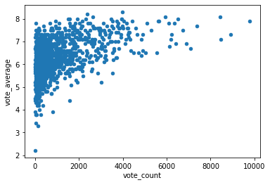

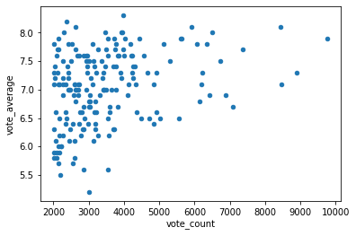

```python
data_vote.plot(x='vote_count', y='vote_average', kind='scatter');
data_vote_2000.plot(x='vote_count', y='vote_average', kind='scatter');
```

```python
data_vote.corr()
```

|  | vote_count | vote_average |
| --- | --- | --- |
| vote_count | 1.000000 | 0.464812 |
| vote_average | 0.464812 | 1.000000 |

```python
 data_vote_2000.corr()
```

|  | vote_count | vote_average |
| --- | --- | --- |
| vote_count | 1.000000 | 0.305343 |
| vote_average | 0.305343 | 1.000000 |

# Research Question 4: What were the most popular produced genres in 2000 compared to 2015?

```python
#Creating a Mask for the release_year 2015
data_2015 = data_genres_dates[data_genres_dates['release_year'] == 2015].copy()
#drop release_year
data_2015.drop('release_year',axis=1, inplace=True)
#value_counts across columns
data_2015 = data_2015.stack().value_counts()
```

```python
data_2000 = data_genres_dates[data_genres_dates['release_year'] == 2000].copy()
#drop release_year
data_2000.drop('release_year',axis=1, inplace=True)
#value_counts across columns
data_2000 = data_2000.stack().value_counts()
```

```python
data_2015.index.sort_values(),data_2000.index.sort_values()

#Adjusting columns to have a match in columns
data_2000['Animation'] = 0
data_2000['Crime'] = 0
data_2000['History'] = 0
data_2000['Horror'] = 0
data_2000['Music'] = 0
data_2000['Western'] = 0

#Updating DataFrames, sort it by index
data_2015 = data_2015.sort_index()
data_2000 = data_2000.sort_index()
```

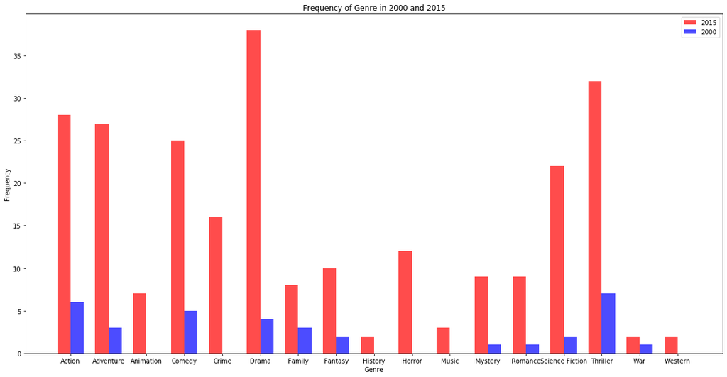

```python
'Creating a plot with a bar chart with 2 bars'
labels = data_2000.index.sort_values()
ind = np.arange(len(data_2015))  # the x locations for the groups
width = 0.35       # the width of the bars

# plot bars
red_bars = plt.bar(ind, data_2015, width, color='r', alpha=.7, label='2015')
white_bars = plt.bar(ind + width, data_2000, width, color='b', alpha=.7, label='2000')

# title and labels
plt.ylabel('Frequency')
plt.xlabel('Genre')
plt.title('Frequency of Genre in 2000 and 2015')
locations = ind + width / 2  # xtick locations
labels = labels # xtick labels
plt.xticks(locations, labels)
plt.rcParams["figure.figsize"] = (20,10)
# legend
plt.legend();
```

# Research Question 5: How did the amount of produced films changed over time?

```python
amount_of_movies = [] #creates a list of tuples for amount of movies

#for loop to create amount_of_movies, years was previously defined
for year in years:
    d = data_genres_dates[data_genres_dates['release_year'] == year] #creates data filtered by every year mentioned in years
    e = len(d.index) #determines the number of rows
    amount_of_movies.append((year, e)) #appends year with respective number of rows

#creates data for list of tuples amount_of_movies
data_amount_of_movies = pandas.DataFrame(amount_of_movies, columns=['release_year', 'amount_of_mvies']).sort_values('release_year').reset_index().drop(['index'], axis=1)
```

|  | release_year | amount_of_mvies |
| --- | --- | --- |
| 0 | 1961 | 1 |
| 1 | 1962 | 1 |
| 2 | 1963 | 1 |
| 3 | 1964 | 2 |
| 4 | 1965 | 1 |
| 5 | 1967 | 1 |
| 6 | 1969 | 1 |
| 7 | 1971 | 4 |
| 8 | 1972 | 1 |
| 9 | 1973 | 2 |
| 10 | 1974 | 1 |
| 11 | 1975 | 3 |
| 12 | 1977 | 2 |
| 13 | 1978 | 2 |
| 14 | 1979 | 4 |
| 15 | 1980 | 2 |
| 16 | 1981 | 6 |
| 17 | 1982 | 3 |
| 18 | 1983 | 5 |
| 19 | 1984 | 4 |
| 20 | 1985 | 2 |
| 21 | 1986 | 1 |
| 22 | 1987 | 4 |
| 23 | 1988 | 2 |
| 24 | 1989 | 4 |
| 25 | 1990 | 4 |
| 26 | 1991 | 2 |
| 27 | 1992 | 5 |
| 28 | 1993 | 7 |
| 29 | 1994 | 5 |
| 30 | 1995 | 8 |
| 31 | 1996 | 13 |
| 32 | 1997 | 8 |
| 33 | 1998 | 11 |
| 34 | 1999 | 22 |
| 35 | 2000 | 14 |
| 36 | 2001 | 18 |
| 37 | 2002 | 24 |
| 38 | 2003 | 30 |
| 39 | 2004 | 43 |
| 40 | 2005 | 51 |
| 41 | 2006 | 68 |
| 42 | 2007 | 92 |
| 43 | 2008 | 82 |
| 44 | 2009 | 116 |
| 45 | 2010 | 132 |
| 46 | 2011 | 156 |
| 47 | 2012 | 88 |
| 48 | 2013 | 65 |
| 49 | 2014 | 70 |
| 50 | 2015 | 93 |

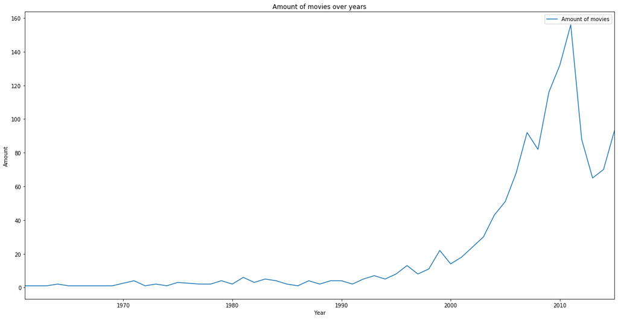

```python
data_amount_of_movies.plot(x='release_year', y='amount_of_mvies', kind='line', figsize=(20,10), title="Amount of movies over years", label="Amount of movies", )
plt.xlabel('Year')
plt.ylabel('Amount');
data_amount_of_movies
```

### Conclusions

The first research question "Which genres are hottest from year to year?" has shown several results, because the hottest genre differed tons . The finding are only in 11 occasions the foremost frequent produced genres was also voted as best genre by the users. altogether remaining occasions the 2 values differed.

The forth research question "What were the foremost popular produced genres in 2000 compared to 2015?" indicate that within the year 2015 dramas were far and away the foremost frequent produced movies, followed by thrillers and action. In 2000 the foremost frequent produced genre was thriller, followed by action and comedies. The bar graph indicates that in 2015 far more movies were produced compared to the year 2000.

All results are limited to the underlying data set and as no advaned statistics were performed, the results can only be treated as indicators and aren't generalizable. Furthermore, one has got to consider that a lot of entries within the dataset are removed thanks to missing data